# EDA: Steam

Grupo7

2024-09-24

# 1. Introducción y definición de objetivos

Al disponer de variables enlazadas directamente a la acogida por parte del público de los diversos títulos de Steam, el principal propósito de esta investigación es llevar a cabo un estudio de mercado sobre los mismos. De este modo, se analizaría si es posible establecer una conexión directa entre la satisfacción del público y otras variables como podrían ser la duración o los tags. Esta última podría resultar sumamente interesante puesto que sería posible explorar las tendencias de los usuarios a la hora de puntuar juegos de determinados géneros o categorías, profundizando así más allá de los aspectos técnicos del videojuego (como el tiempo de contenido), en lo que el usuario busca experimentar sensorial, emocional o psicológicamente a la hora de decidir qué jugar. Asimismo, dado que las valoraciones profesionales no tienen por qué coincidir con las de los usuarios, también sería de interés estudiar cómo difieren entre sí.

Por otro lado, también se pretende llevar a cabo un análisis sobre los propios desarrolladores, descubriendo así cuáles son los géneros que tienen más lanzamientos cada año y si es posible establecer una relación con las valoraciones de lanzamientos del mismo género de años anteriores.

Precisamente debido a los objetivos de este estudio estadístico, se ha decidido no analizar las variables ‘positivity_ratio’ y ‘extra_content_length’, ya que no son relevantes en relación al análisis de otras variables ni tampoco por sí mismas.

# 2. Importación de datos y carga de paquetes

```r
library(tidyverse)
library(summarytools)
library(GGally)
library(gt)
library(flextable)
library(knitr)
library(corrplot)
library(kableExtra)
library(ggplot2)
library(tidyr)
library(dplyr)
library(psych)
```

```r
#Lee el dataset al que hemos llamado datos
datos <- readxl::read_excel("dataset.xlsx")
```

# 3. Diccionario de datos

- `id`: Identificador del juego (identificador)
- `name`: Nombre del juego (identificador)
- `year`: Año de salida al mercado (numérica discreta)
- `metacritic_rating`: Nota media de valoración profesional (numérica discreta, valor sobre 100)
- `reviewer_rating`: Nota media de la valoración de los usuarios (numérica discreta, sobre 10)
- `positivity_ratio`: Ratio de positividad, cociente entre las valoraciones positivas y las valoraciones negativas (numérica continua). No se va a usar.
- `to_beat_main`: Tiempo medio necesario para superar el juego principal (numérica continua, medida en horas)
- `to_beat_extra`: Tiempo medio necesario para superar el juego principal y contenido extra (numérica continua, medida en horas)
- `to_beat_completionist`: Tiempo medio para completar todo el contenido del juego y obtener todo sus logros (numérica continua, medida en horas)
- `extra_content_length`: Diferencia de tiempo entre el contenido principal y el extra (numérica continua, medida en horas). No se va a usar.
- `tags`: Categorías o “tags” bajo las que se encuentra inscrito cada juego (categórica multinivel)

# 4. Análisis exploratorio de datos

El estudio de este dataset constará de dos partes, siendo la primera un análisis univariante de las variables de las que dispone este dataset, sin incluir aquellas que se ha explicado con anterioridad que no son de interés.

## 4.1. Datos univariantes

### 4.1.1. Variable ‘year’

```r
Años <- cut(datos$year, breaks = 6)  # Definimos 6 intervalos

# Crea la tabla de frecuencias
tabla_frecuencias2 <- as.data.frame(table(Años))

# Calcula la frecuencia relativa (f), frecuencia acumulada (N) y frecuencia relativa acumulada (F)
tabla_frecuencias2 <- tabla_frecuencias2 %>%
  mutate(f = Freq / sum(Freq),         # Frecuencia relativa
         N = cumsum(Freq),             # Frecuencia acumulada
         F = cumsum(f))                # Frecuencia relativa acumulada

# Muestra la tabla con formato
knitr::kable(tabla_frecuencias2, digits = 4)
```

| Años | Freq | f | N | F |
| --- | --- | --- | --- | --- |
| (1997,2001] | 14 | 0.0002 | 14 | 0.0002 |
| (2001,2006] | 15 | 0.0002 | 29 | 0.0005 |
| (2006,2010] | 961 | 0.0151 | 990 | 0.0156 |
| (2010,2014] | 2716 | 0.0428 | 3706 | 0.0584 |
| (2014,2019] | 21130 | 0.3331 | 24836 | 0.3915 |
| (2019,2023] | 38607 | 0.6085 | 63443 | 1.0000 |

Gráfico de barras y resumen numérico para una mejor visualización de la cantidad de juegos subidos a Steam en cada año.

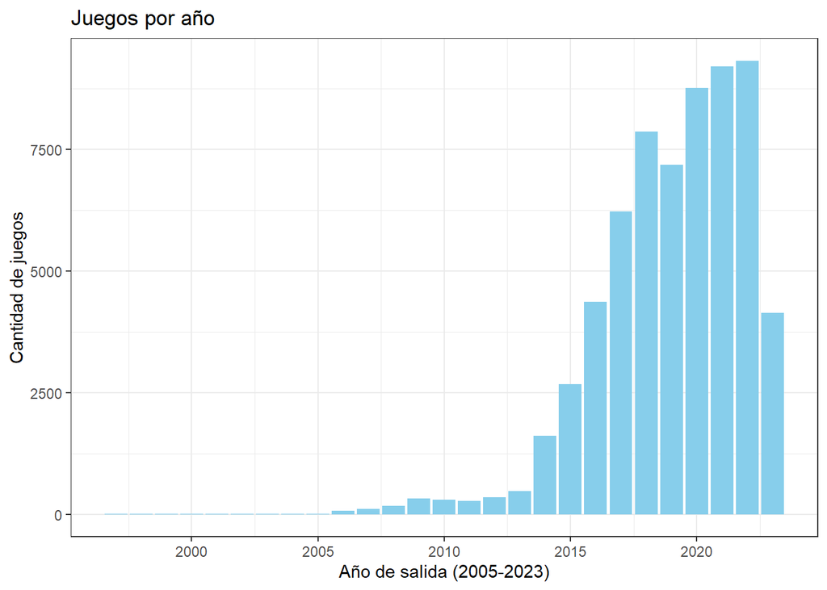

```r
datos |>
  # Inicia la visualización
  ggplot(aes(x = year)) +
  # Añade un gráfico de barras, rellenando las barras
  geom_bar(fill = "skyblue") +
  theme_bw() +
  # Establece los títulos del gráfico, eje x, y eje y.
  labs(title = "Juegos por año",
       x = "Año de salida (2005-2023)",
       y = "Cantidad de juegos")
```

```r
datos |> descr(year)
```

```
## Descriptive Statistics
## datos$year
## N: 63543
##
##                         year
## ----------------- ----------
##              Mean    2019.03
##           Std.Dev       2.85
##               Min    1997.00
##                Q1    2017.00
##            Median    2019.00
##                Q3    2021.00
##               Max    2023.00
##               MAD       2.97
##               IQR       4.00
##                CV       0.00
##          Skewness      -1.09
##       SE.Skewness       0.01
##          Kurtosis       2.13
##           N.Valid   63443.00
##         Pct.Valid      99.84
```

Se observa cómo la producción de los videojuegos lleva en auge las últimas décadas, haciendo un salto en 2015, además de cómo se frenó la caída de la industria en el año 2020 debido a la pandemia mundial y a la cuarentena.

### 4.1.2. Variable ‘metacritic_rating’

Tabla de frecuencias de las críticas de expertos divididas en 7 intervalos:

```r
# Remueve NA's de los datos
datos_filtrados_metacritic <- datos %>%
  filter(!is.na(metacritic_rating))

# Define los intervalos manualmente para que no haya valores que se salgan de los mínimos y máximos
breaks <- seq(20, max(datos_filtrados_metacritic$metacritic_rating, na.rm = TRUE), length.out = 8)  # 7 intervalos

# Corta los datos en los intervalos especificados
metacritic_rating <- cut(datos_filtrados_metacritic$metacritic_rating, breaks = breaks)

# Crea la tabla de frecuencias
tabla_frecuencias2 <- as.data.frame(table(metacritic_rating))

# Calcula las frecuencias relativas y acumuladas
tabla_frecuencias2 <- tabla_frecuencias2 %>%
  mutate(f = Freq / sum(Freq),         # Frecuencia relativa
         N = cumsum(Freq),             # Frecuencia acumulada
         F = cumsum(f))                # Frecuencia relativa acumulada

# Muestra la tabla con formato
knitr::kable(tabla_frecuencias2, digits = 4)
```

| metacritic_rating | Freq | f | N | F |
| --- | --- | --- | --- | --- |
| (20,31] | 8 | 0.0020 | 8 | 0.0020 |
| (31,42] | 40 | 0.0102 | 48 | 0.0123 |
| (42,53] | 155 | 0.0396 | 203 | 0.0519 |
| (53,64] | 522 | 0.1333 | 725 | 0.1852 |
| (64,75] | 1406 | 0.3591 | 2131 | 0.5443 |
| (75,86] | 1543 | 0.3941 | 3674 | 0.9384 |
| (86,97] | 241 | 0.0616 | 3915 | 1.0000 |

Gráfico de barras:

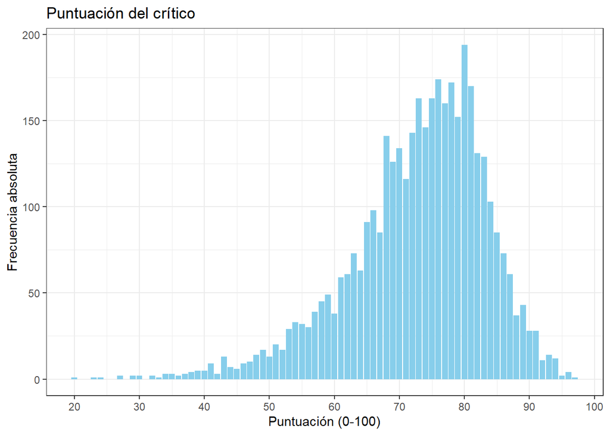

```r
datos |>
  # Inicia una visualización
  ggplot(aes(x = metacritic_rating)) +
  # Añade un gráfico de barras, rellenando las barras
  geom_bar(fill = "skyblue") +
  theme_bw() +
  # Establece los títulos del gráfico, eje x, y eje y.
  labs(title = "Puntuación del crítico",
       x = "Puntuación (0-100)",
       y = "Frecuencia absoluta") +
   scale_x_continuous(breaks = seq(20, 100, by = 10))  # Define más marcas en el eje X cada 10 unidades
```

En este gráfico se observa que las puntuaciones más frecuentes se encuentran entre los 60 y 85 puntos. La puntuación más frecuente, es decir, la moda, son 80 puntos, llegando a una frecuencia de casi 200.

```r
summary(datos$metacritic_rating)
```

```
##    Min. 1st Qu.  Median    Mean 3rd Qu.    Max.    NA's
##   20.00   67.00   74.00   72.84   80.00   97.00   59627
```

La información se amplía con este resumen en el que se destaca que la puntuación media son 72,84 puntos. La nota más baja son 20 puntos y la más alta 97 puntos. Se concluye, entonces, que no hay ningún juego que tenga una puntuación de 100.

### 4.1.3. Variable ‘reviewer_rating’

Tabla de frecuencias por cada valor:

```r
# Crea una tabla de frecuencias
tabla_frecuencias2 <- as.data.frame(table(datos$reviewer_rating))

# Calcula la frecuencia relativa (f), frecuencia acumulada (N) y frecuencia relativa acumulada (F)
tabla_frecuencias2 <- tabla_frecuencias2 %>%
  mutate(f = Freq / sum(Freq),         # Frecuencia relativa
         N = cumsum(Freq),             # Frecuencia acumulada
         F = cumsum(f))                # Frecuencia relativa acumulada

#Muestra la tabla con formato
knitr::kable(tabla_frecuencias2, digits = 4)
```

| Var1 | Freq | f | N | F |
| --- | --- | --- | --- | --- |
| 1 | 11 | 0.0002 | 11 | 0.0002 |
| 2 | 64 | 0.0014 | 75 | 0.0017 |
| 3 | 322 | 0.0072 | 397 | 0.0089 |
| 4 | 2136 | 0.0479 | 2533 | 0.0568 |
| 5 | 11902 | 0.2667 | 14435 | 0.3234 |
| 6 | 8023 | 0.1798 | 22458 | 0.5032 |
| 7 | 9287 | 0.2081 | 31745 | 0.7113 |
| 8 | 11919 | 0.2671 | 43664 | 0.9784 |
| 9 | 965 | 0.0216 | 44629 | 1.0000 |

Gráfico de barras:

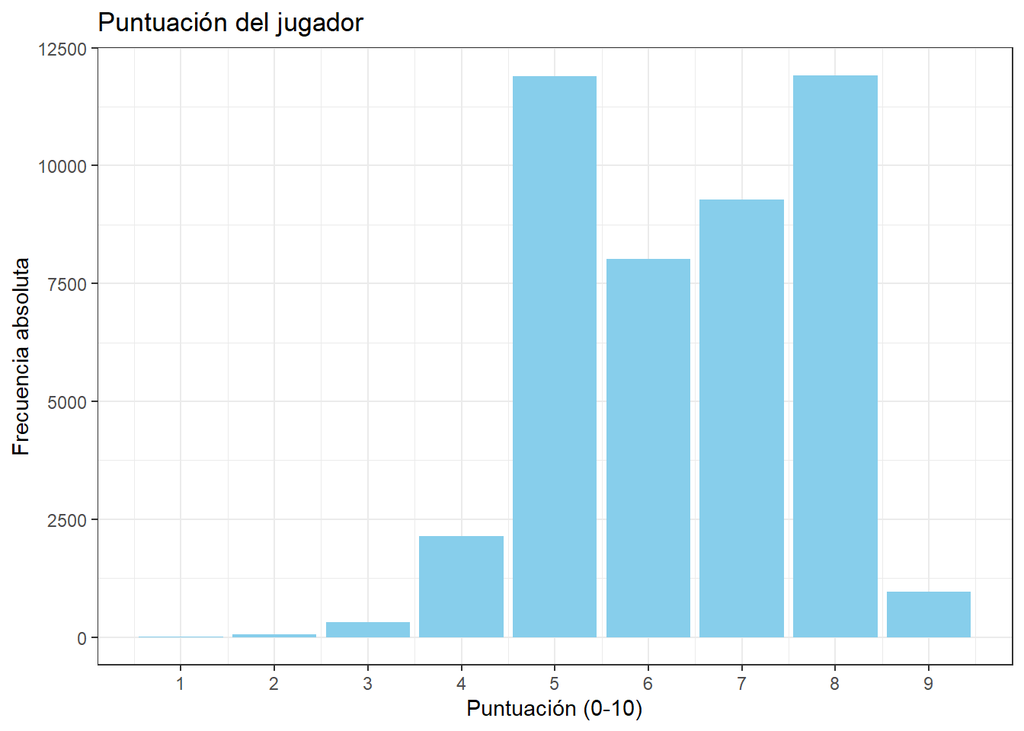

```r
datos |>
  # Inicia una visualización
  ggplot(aes(x = reviewer_rating)) +
  # Añade un gráfico de barras, rellenando las barras
   geom_bar(fill = "skyblue") +
  theme_bw() +
  # Establece los títulos del gráfico, eje x, y eje y.
  labs(title = "Puntuación del jugador",
       x = "Puntuación (0-10)",
       y = "Frecuencia absoluta") +
  scale_x_continuous(breaks = seq(0, 10, by = 1))  # Define más marcas en el eje X cada unidad
```

En este gráfico se observa que las puntuaciones más frecuentes se encuentran entre los 5 y 8 puntos. La puntuación más frecuente, es decir, la moda, son 8 puntos, seguido muy de cerca por los 5 puntos.

```r
summary(datos$reviewer_rating)
```

```
##    Min. 1st Qu.  Median    Mean 3rd Qu.    Max.    NA's
##   1.000   5.000   6.000   6.416   8.000   9.000   18914
```

### 4.1.4. Variable ‘to_beat_main’

Tabla de frecuencias dividida en 10 intervalos:

```r
# Definir intervalos
Tiempo <- cut(datos$to_beat_main, breaks = 10)  # Definimos intervalos

# Crea la tabla de frecuencias
tabla_frecuencias2 <- as.data.frame(table(Tiempo))

# Calcular la frecuencia relativa (f), frecuencia acumulada (N) y frecuencia relativa acumulada (F)
tabla_frecuencias2 <- tabla_frecuencias2 %>%
  mutate(f = Freq / sum(Freq),         # Frecuencia relativa
         N = cumsum(Freq),             # Frecuencia acumulada
         F = cumsum(f))                # Frecuencia relativa acumulada

# Mostrar la tabla con formato usando knitr::kable
knitr::kable(tabla_frecuencias2, digits = 4,
             caption = "Valores de 'to_beat_main'")
```

Valores de ‘to_beat_main’

| Tiempo | Freq | f | N | F |
| --- | --- | --- | --- | --- |
| (-2.1,211] | 17757 | 0.9975 | 17757 | 0.9975 |
| (211,421] | 18 | 0.0010 | 17775 | 0.9985 |
| (421,632] | 8 | 0.0004 | 17783 | 0.9990 |
| (632,842] | 11 | 0.0006 | 17794 | 0.9996 |
| (842,1.05e+03] | 3 | 0.0002 | 17797 | 0.9998 |
| (1.05e+03,1.26e+03] | 1 | 0.0001 | 17798 | 0.9998 |
| (1.26e+03,1.47e+03] | 1 | 0.0001 | 17799 | 0.9999 |
| (1.47e+03,1.68e+03] | 0 | 0.0000 | 17799 | 0.9999 |
| (1.68e+03,1.9e+03] | 0 | 0.0000 | 17799 | 0.9999 |
| (1.9e+03,2.11e+03] | 2 | 0.0001 | 17801 | 1.0000 |

Como en la tabla de frecuencias no se aprecian bien los intervalos debido a la inmensa cantidad de valores, se ha seleccionado un rango de 0 a 50 horas, que es donde se encuentran la mayoría de valores.

```r
# Filtrar los datos para eliminar valores NA
datos_filtrados_main1 <- datos %>%
  filter(!is.na(to_beat_main))

# Truncar los valores mayores a 50
datos_filtrados_main1$to_beat_main <- ifelse(datos_filtrados_main1$to_beat_main > 50, 51, datos_filtrados_main1$to_beat_main)

# Crear las etiquetas personalizadas para los intervalos
etiquetas_intervalos <- c(paste0("[", seq(0, 45, by = 5), ", ", seq(5, 50, by = 5), ")"), "Más de 50")

# Definir los intervalos en el rango de 0 a 50 horas, más un intervalo adicional para valores mayores a 50
Tiempo <- cut(datos_filtrados_main1$to_beat_main,
              breaks = c(seq(0, 50, length.out = 11), Inf),   # Inf para incluir valores mayores a 50
              labels = etiquetas_intervalos,
              right = FALSE)  # Intervalos cerrados a la izquierda y abiertos a la derecha

# Crear la tabla de frecuencias
tabla_frecuencias2 <- as.data.frame(table(Tiempo))

# Calcular la frecuencia relativa (f), frecuencia acumulada (N) y frecuencia relativa acumulada (F)
tabla_frecuencias2 <- tabla_frecuencias2 %>%
  mutate(f = Freq / sum(Freq),         # Frecuencia relativa
         N = cumsum(Freq),             # Frecuencia acumulada
         F = cumsum(f))                # Frecuencia relativa acumulada

# Mostrar la tabla con formato usando knitr::kable
knitr::kable(tabla_frecuencias2, digits = 4,
             caption = "'to_beat_main'")
```

‘to_beat_main’

| Tiempo | Freq | f | N | F |
| --- | --- | --- | --- | --- |
| [0, 5) | 10031 | 0.5635 | 10031 | 0.5635 |
| [5, 10) | 3739 | 0.2100 | 13770 | 0.7736 |
| [10, 15) | 1488 | 0.0836 | 15258 | 0.8571 |
| [15, 20) | 821 | 0.0461 | 16079 | 0.9033 |
| [20, 25) | 513 | 0.0288 | 16592 | 0.9321 |
| [25, 30) | 293 | 0.0165 | 16885 | 0.9485 |
| [30, 35) | 250 | 0.0140 | 17135 | 0.9626 |
| [35, 40) | 157 | 0.0088 | 17292 | 0.9714 |
| [40, 45) | 109 | 0.0061 | 17401 | 0.9775 |
| [45, 50) | 76 | 0.0043 | 17477 | 0.9818 |
| Más de 50 | 324 | 0.0182 | 17801 | 1.0000 |

A continuación el gráfico de densidad de ‘to_beat_main’ sin agrupar datos:

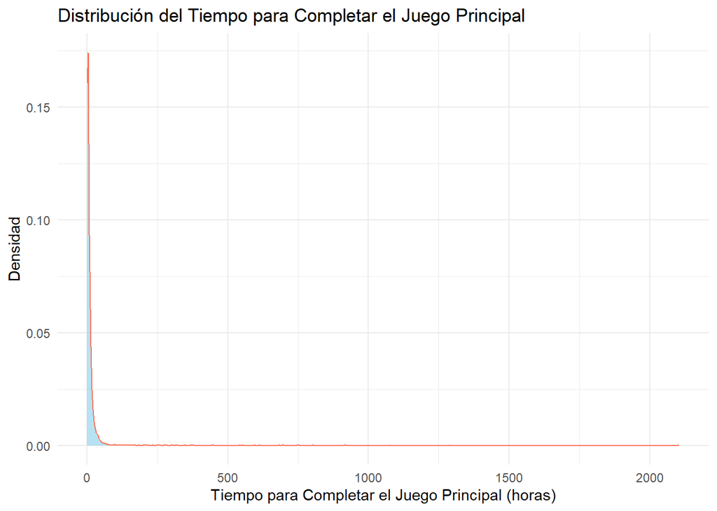

```r
# Filtrar los datos para eliminar valores NA
datos_filtrados_main2 <- datos %>%
  filter(!is.na(to_beat_main))

# Crear el gráfico de densidad
ggplot(datos_filtrados_main2, aes(x = to_beat_main)) +
  geom_density(fill = "skyblue", color = "coral1", alpha = 0.6) +
  labs(title = "Distribución del Tiempo para Completar el Juego Principal",
       x = "Tiempo para Completar el Juego Principal (horas)",
       y = "Densidad") +
  theme_minimal()
```

Dado que la existencia de muy pocos datos con valores muy grandes dificulta el análisis del gráfico de densidad, se ha optado por hacer otro gráfico de densidad agrupando los datos más grandes, a partir de 50 horas, en un mismo valor. De este modo, es posible analizar con mayor precisión los datos en este rango de 0 a 50 horas, que es donde se encuentran la mayoría de ellos. Al aplicar este cambio, se obtiene el siguiente gráfico de densidad:

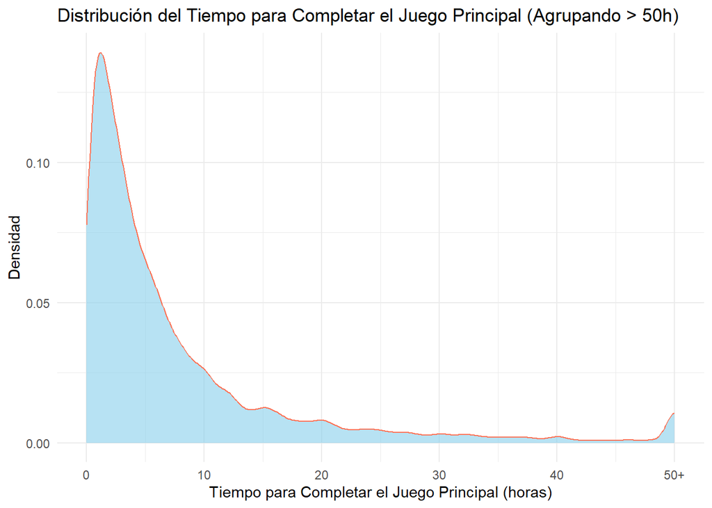

```r
# Agrupar valores mayores a 50 horas en una nueva categoría
datos_filtrados_main2 <- datos_filtrados_main2 %>%
  mutate(to_beat_main_grouped = ifelse(to_beat_main > 50, 50, to_beat_main))

# Crear el gráfico de densidad usando la variable agrupada
ggplot(datos_filtrados_main2, aes(x = to_beat_main_grouped)) +
  geom_density(fill = "skyblue", color = "coral1", alpha = 0.6) +
  labs(title = "Distribución del Tiempo para Completar el Juego Principal (Agrupando > 50h)",
       x = "Tiempo para Completar el Juego Principal (horas)",
       y = "Densidad") +
  theme_minimal() +
  scale_x_continuous(breaks = c(seq(0, 50, by = 10)), labels = c(seq(0, 40, by = 10), "50+"))
```

A partir de estos dos gráficos, entonces, es posible establecer una clara predominancia de juegos cuyo contenido principal tan solo requieren entre 0 y 4 horas para completarse, con un pico claro en unas 2 horas. A partir de entonces, la densidad de juegos no hace más que decrecer a medida que aumenta la variable del tiempo, con un leve pico en 15 horas. Ciertamente, en este último gráfico se puede observar que la densidad vuelve a crecer a partir de 47 aproximadamente, pero eso se debe a la agrupación de esos datos cuyo tiempo es mayor a 50. No obstante, si se observa con detenimiento el primer gráfico de densidad, se observa que en realidad, la densidad de juegos a partir de las 50 horas se mantiene bastante estable.

A continuación, el resumen estadístico de la variable to_beat_main:

```r
summary(datos$to_beat_main)
```

```
##    Min. 1st Qu.  Median    Mean 3rd Qu.    Max.    NA's
##    0.01    1.63    4.00    9.49    9.01 2105.84   45742
```

La información se amplía y precisa con este resumen en el que se destaca que el tiempo medio es de 9,49 horas. El tiempo más bajo es de 0,01 horas y el más alto, de 2105,84 horas. Por otro lado, la mediana se encuentra en las 4 horas.

### 4.1.5. Variable ‘to_beat_extra’

Tabla de frecuencias con 10 intervalos:

```r
Tiempo <- cut(datos$to_beat_extra, breaks = 10)  # Definimos intervalos

# Crea la tabla de frecuencias
tabla_frecuencias2 <- as.data.frame(table(Tiempo))

# Calcula la frecuencia relativa (f), frecuencia acumulada (N) y frecuencia relativa acumulada (F)
tabla_frecuencias2 <- tabla_frecuencias2 %>%
  mutate(f = Freq / sum(Freq),         # Frecuencia relativa
         N = cumsum(Freq),             # Frecuencia acumulada
         F = cumsum(f))                # Frecuencia relativa acumulada

# Mostrar la tabla con formato usando knitr::kable
knitr::kable(tabla_frecuencias2, digits = 4,
             caption = "'Valores de to_beat_extra'")
```

‘Valores de to_beat_extra’

| Tiempo | Freq | f | N | F |
| --- | --- | --- | --- | --- |
| (-6.47,650] | 13390 | 0.9972 | 13390 | 0.9972 |
| (650,1.3e+03] | 22 | 0.0016 | 13412 | 0.9989 |
| (1.3e+03,1.95e+03] | 8 | 0.0006 | 13420 | 0.9995 |
| (1.95e+03,2.6e+03] | 0 | 0.0000 | 13420 | 0.9995 |
| (2.6e+03,3.25e+03] | 4 | 0.0003 | 13424 | 0.9998 |
| (3.25e+03,3.9e+03] | 2 | 0.0001 | 13426 | 0.9999 |
| (3.9e+03,4.55e+03] | 0 | 0.0000 | 13426 | 0.9999 |
| (4.55e+03,5.2e+03] | 0 | 0.0000 | 13426 | 0.9999 |
| (5.2e+03,5.85e+03] | 0 | 0.0000 | 13426 | 0.9999 |
| (5.85e+03,6.51e+03] | 1 | 0.0001 | 13427 | 1.0000 |

Dado que en la tabla de frecuencias no se aprecian bien los intervalos debido a la inmensa cantidad de valores, se ha seleccionado un rango de 0 a 50 horas, que es donde se encuentran la mayoría de valores, tal y como ocurría con el caso anterior.

```r
# Filtrar los datos para eliminar valores NA
datos_filtrados_extra1 <- datos %>%
  filter(!is.na(to_beat_extra))

# Truncar los valores mayores a 50
datos_filtrados_extra1$to_beat_extra <- ifelse(datos_filtrados_extra1$to_beat_extra > 50, 51, datos_filtrados_extra1$to_beat_extra)

# Definir los intervalos en el rango de 0 a 50 horas, más un intervalo adicional para valores mayores a 50
Tiempo <- cut(datos_filtrados_extra1$to_beat_extra,
              breaks = c(seq(0, 50, length.out = 11), Inf),   # Inf para incluir valores mayores a 50
              labels = etiquetas_intervalos,
              right = FALSE)  # Intervalos cerrados a la izquierda y abiertos a la derecha

# Crea la tabla de frecuencias
tabla_frecuencias2 <- as.data.frame(table(Tiempo))

# Calcula la frecuencia relativa (f), frecuencia acumulada (N) y frecuencia relativa acumulada (F)
tabla_frecuencias2 <- tabla_frecuencias2 %>%
  mutate(f = Freq / sum(Freq),         # Frecuencia relativa
         N = cumsum(Freq),             # Frecuencia acumulada
         F = cumsum(f))                # Frecuencia relativa acumulada

# Mostrar la tabla con formato usando knitr::kable
knitr::kable(tabla_frecuencias2, digits = 4,
             caption = "'to_beat_extra'")
```

‘to_beat_extra’

| Tiempo | Freq | f | N | F |
| --- | --- | --- | --- | --- |
| [0, 5) | 4887 | 0.3640 | 4887 | 0.3640 |
| [5, 10) | 3133 | 0.2333 | 8020 | 0.5973 |
| [10, 15) | 1658 | 0.1235 | 9678 | 0.7208 |
| [15, 20) | 885 | 0.0659 | 10563 | 0.7867 |
| [20, 25) | 644 | 0.0480 | 11207 | 0.8347 |
| [25, 30) | 408 | 0.0304 | 11615 | 0.8650 |
| [30, 35) | 356 | 0.0265 | 11971 | 0.8916 |
| [35, 40) | 214 | 0.0159 | 12185 | 0.9075 |
| [40, 45) | 203 | 0.0151 | 12388 | 0.9226 |
| [45, 50) | 184 | 0.0137 | 12572 | 0.9363 |
| Más de 50 | 855 | 0.0637 | 13427 | 1.0000 |

A continuación el gráfico de densidad de ‘to_beat_extra’ sin agrupar datos:

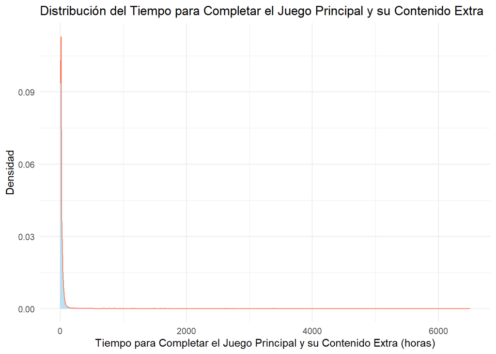

```r
# Filtrar los datos para eliminar valores NA
datos_filtrados_extra2 <- datos %>%
  filter(!is.na(to_beat_extra))

# Crear el gráfico de densidad
ggplot(datos_filtrados_extra2, aes(x = to_beat_extra)) +
  geom_density(fill = "skyblue", color = "coral1", alpha = 0.6) +
  labs(title = "Distribución del Tiempo para Completar el Juego Principal y su Contenido Extra",
       x = "Tiempo para Completar el Juego Principal y su Contenido Extra (horas)",
       y = "Densidad") +
  theme_minimal()
```

Tal y como ocurría en el análisis de la variable anterior, la existencia de muy pocos datos con valores muy grandes dificulta el análisis del gráfico de densidad. Consecuentemente, se ha optado por hacer otro gráfico de densidad agrupando los datos más grandes, a partir de 50 horas, en un mismo valor. De este modo, es posible analizar con mayor precisión los datos en este rango de 0 a 50 horas, que es donde se encuentran la mayoría de ellos. Al aplicar este cambio, se obtiene el siguiente gráfico de densidad:

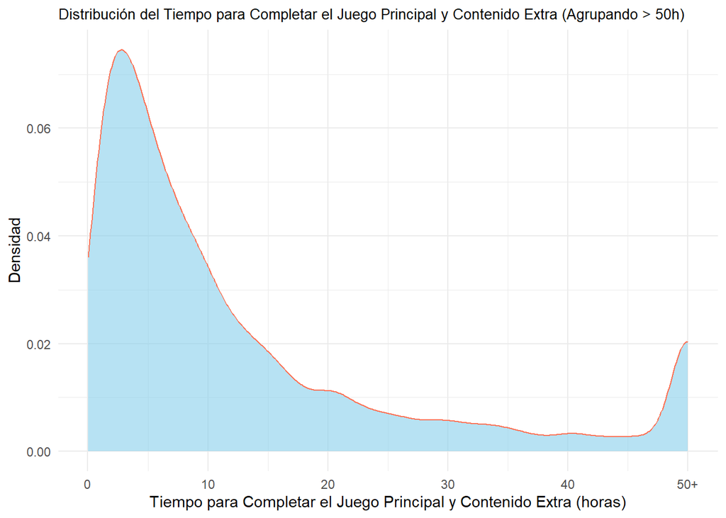

```r
# Agrupar valores mayores a 50 horas en una nueva categoría
datos_filtrados_extra2 <- datos_filtrados_extra2 %>%
  mutate(to_beat_extra_grouped = ifelse(to_beat_extra > 50, 50, to_beat_extra))

# Crear el gráfico de densidad usando la variable agrupada
ggplot(datos_filtrados_extra2, aes(x = to_beat_extra_grouped)) +
  geom_density(fill = "skyblue", color = "coral1", alpha = 0.6) +
  labs(title = "Distribución del Tiempo para Completar el Juego Principal y Contenido Extra (Agrupando > 50h)",
       x = "Tiempo para Completar el Juego Principal y Contenido Extra (horas)",
       y = "Densidad") +
  theme_minimal() +
  theme(plot.title = element_text(size = 10)) +  # Ajuste del tamaño del título
  scale_x_continuous(breaks = c(seq(0, 50, by = 10)), labels = c(seq(0, 40, by = 10), "50+"))
```

A partir de estos dos gráficos, entonces, es posible establecer una clara predominancia de juegos cuyo contenido principal y extras tan solo requieren entre 0 y 10 horas para completarse, con un pico claro en unas 3 horas. A partir de entonces, la densidad de juegos no hace más que decrecer a medida que aumenta la variable del tiempo, con un leve pico en 20 horas. Ciertamente, en este último gráfico se puede observar que la densidad vuelve a crecer a partir de 47 aproximadamente, pero eso se debe a la agrupación de esos datos cuyo tiempo es mayor a 50. No obstante, si se observa con detenimiento el primer gráfico de densidad, se observa que en realidad, la densidad de juegos a partir de las 50 horas se mantiene bastante estable.

A continuación, el resumen estadístico de la variable to_beat_extra:

```r
summary(datos$to_beat_extra)
```

```
##    Min. 1st Qu.  Median    Mean 3rd Qu.    Max.    NA's
##    0.03    3.31    7.50   20.00   16.50 6500.00   50116
```

La información se amplía y precisa con este resumen en el que se destaca que el tiempo medio es de 20 horas. El tiempo más bajo es de 0,03 horas y el más alto, de 6500 horas. Por otro lado, la mediana se encuentra en las 7,5 horas.

### 4.1.6. Variable ‘to_beat_completionist’

Tabla de frecuencia con 10 intervalos:

```r
Tiempo <- cut(datos$to_beat_completionist, breaks = 10)  # Definimos intervalos

# Crea la tabla de frecuencias
tabla_frecuencias2 <- as.data.frame(table(Tiempo))

# Calcula la frecuencia relativa (f), frecuencia acumulada (N) y frecuencia relativa acumulada (F)
tabla_frecuencias2 <- tabla_frecuencias2 %>%
  mutate(f = Freq / sum(Freq),         # Frecuencia relativa
         N = cumsum(Freq),             # Frecuencia acumulada
         F = cumsum(f))                # Frecuencia relativa acumulada

# Mostrar la tabla con formato usando knitr::kable
knitr::kable(tabla_frecuencias2, digits = 4,
             caption = "'Valores de to_beat_completionist'")
```

‘Valores de to_beat_completionist’

| Tiempo | Freq | f | N | F |
| --- | --- | --- | --- | --- |
| (-15.3,1.53e+03] | 15995 | 0.9974 | 15995 | 0.9974 |
| (1.53e+03,3.06e+03] | 22 | 0.0014 | 16017 | 0.9988 |
| (3.06e+03,4.59e+03] | 11 | 0.0007 | 16028 | 0.9995 |
| (4.59e+03,6.13e+03] | 4 | 0.0002 | 16032 | 0.9998 |
| (6.13e+03,7.66e+03] | 0 | 0.0000 | 16032 | 0.9998 |
| (7.66e+03,9.19e+03] | 0 | 0.0000 | 16032 | 0.9998 |
| (9.19e+03,1.07e+04] | 3 | 0.0002 | 16035 | 0.9999 |
| (1.07e+04,1.23e+04] | 0 | 0.0000 | 16035 | 0.9999 |
| (1.23e+04,1.38e+04] | 0 | 0.0000 | 16035 | 0.9999 |
| (1.38e+04,1.53e+04] | 1 | 0.0001 | 16036 | 1.0000 |

De nuevo, como en la tabla de frecuencias no se aprecian bien los intervalos debido a la inmensa cantidad de valores, se ha seleccionado un rango de 0 a 50 horas, que es donde se encuentran la mayoría de valores.

```r
# Filtrar los datos para eliminar valores NA
datos_filtrados_completionist1 <- datos %>%
  filter(!is.na(to_beat_completionist))

# Truncar los valores mayores a 50
datos_filtrados_completionist1$to_beat_completionist <- ifelse(datos_filtrados_completionist1$to_beat_completionist > 50, 51, datos_filtrados_completionist1$to_beat_completionist)

# Definir los intervalos en el rango de 0 a 50 horas, más un intervalo adicional para valores mayores a 50
Tiempo <- cut(datos_filtrados_completionist1$to_beat_completionist,
              breaks = c(seq(0, 50, length.out = 11), Inf),   # Inf para incluir valores mayores a 50
              labels = etiquetas_intervalos,
              right = FALSE)  # Intervalos cerrados a la izquierda y abiertos a la derecha

# Crea la tabla de frecuencias
tabla_frecuencias2 <- as.data.frame(table(Tiempo))

# Calcula la frecuencia relativa (f), frecuencia acumulada (N) y frecuencia relativa acumulada (F)
tabla_frecuencias2 <- tabla_frecuencias2 %>%
  mutate(f = Freq / sum(Freq),         # Frecuencia relativa
         N = cumsum(Freq),             # Frecuencia acumulada
         F = cumsum(f))                # Frecuencia relativa acumulada

# Mostrar la tabla con formato usando knitr::kable
knitr::kable(tabla_frecuencias2, digits = 4,
             caption = "'to_beat_completionist'")
```

‘to_beat_completionist’

| Tiempo | Freq | f | N | F |
| --- | --- | --- | --- | --- |
| [0, 5) | 6127 | 0.3821 | 6127 | 0.3821 |
| [5, 10) | 2991 | 0.1865 | 9118 | 0.5686 |
| [10, 15) | 1730 | 0.1079 | 10848 | 0.6765 |
| [15, 20) | 1047 | 0.0653 | 11895 | 0.7418 |
| [20, 25) | 673 | 0.0420 | 12568 | 0.7837 |
| [25, 30) | 521 | 0.0325 | 13089 | 0.8162 |
| [30, 35) | 376 | 0.0234 | 13465 | 0.8397 |
| [35, 40) | 323 | 0.0201 | 13788 | 0.8598 |
| [40, 45) | 268 | 0.0167 | 14056 | 0.8765 |
| [45, 50) | 213 | 0.0133 | 14269 | 0.8898 |
| Más de 50 | 1767 | 0.1102 | 16036 | 1.0000 |

A continuación el gráfico de densidad de ‘to_beat_completionist’ sin agrupar datos:

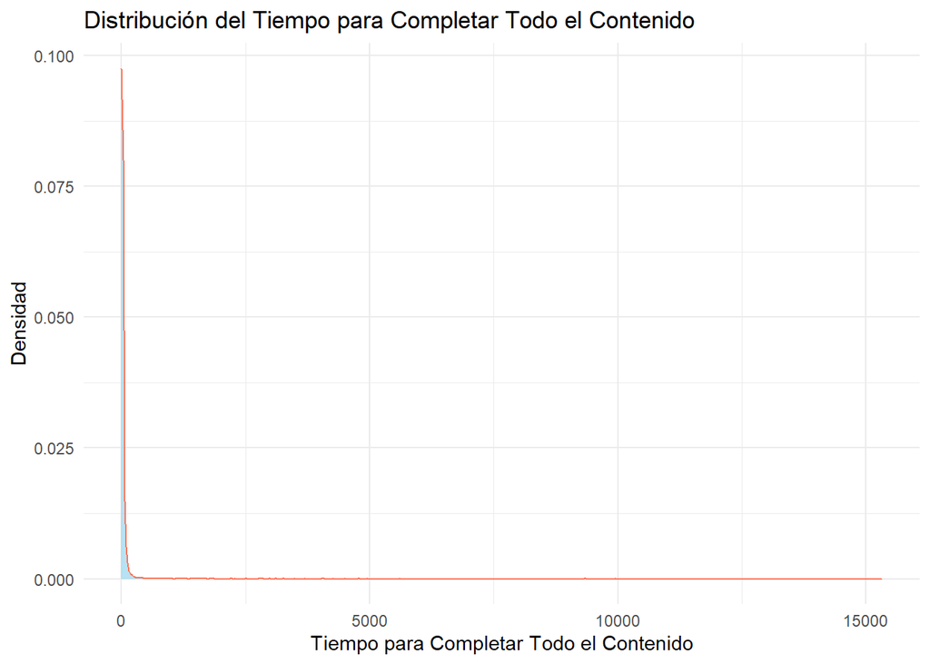

```r
# Filtrar los datos para eliminar valores NA
datos_filtrados_completionist2 <- datos %>%
  filter(!is.na(to_beat_completionist))

# Crear el gráfico de densidad
ggplot(datos_filtrados_completionist2, aes(x = to_beat_completionist)) +
  geom_density(fill = "skyblue", color = "coral1", alpha = 0.6) +
  labs(title = "Distribución del Tiempo para Completar Todo el Contenido",
       x = "Tiempo para Completar Todo el Contenido",
       y = "Densidad") +
  theme_minimal()
```

Similar a los casos anteriores, la existencia de muy pocos datos con valores muy grandes dificulta el análisis del gráfico de densidad. Por lo tanto, se ha optado por hacer otro gráfico de densidad agrupando los datos más grandes, a partir de 50 horas, en un mismo valor. De este modo, es posible analizar con mayor precisión los datos en este rango de 0 a 50 horas, que es donde se encuentran la mayoría de ellos. Al aplicar este cambio, se obtiene el siguiente gráfico de densidad:

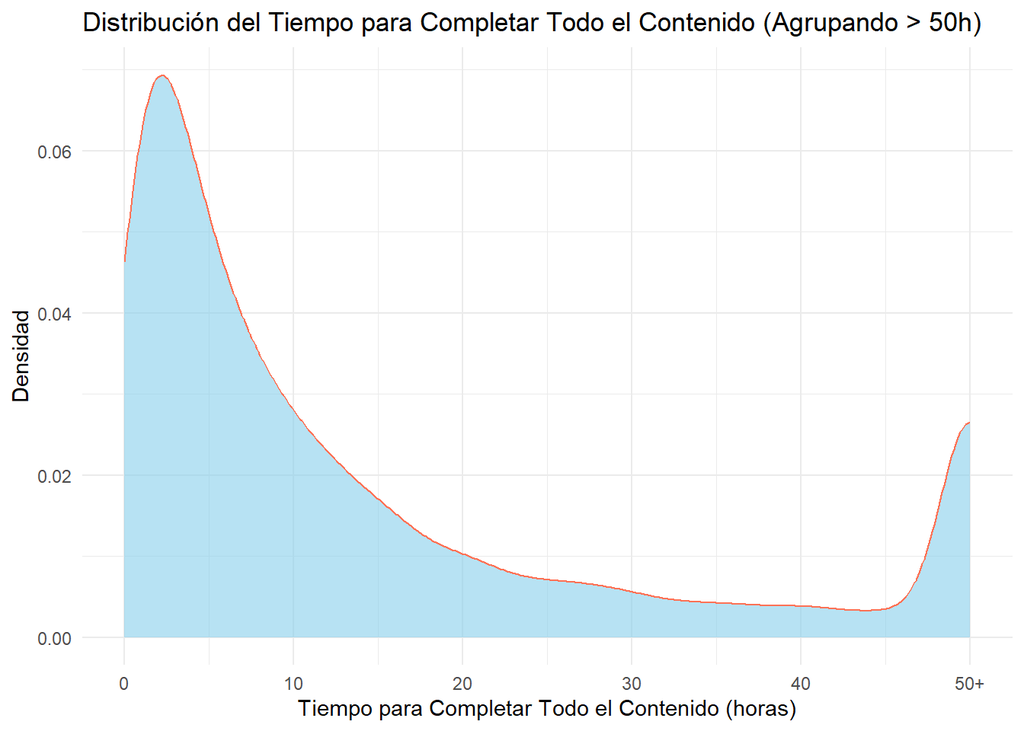

```r
# Agrupar valores mayores a 50 horas en una nueva categoría
datos_filtrados_completionist2 <- datos_filtrados_completionist2 %>%
  mutate(to_beat_completionist_grouped = ifelse(to_beat_completionist > 50, 50, to_beat_completionist))

# Crear el gráfico de densidad usando la variable agrupada
ggplot(datos_filtrados_completionist2, aes(x = to_beat_completionist_grouped)) +
  geom_density(fill = "skyblue", color = "coral1", alpha = 0.6) +
  labs(title = "Distribución del Tiempo para Completar Todo el Contenido (Agrupando > 50h)",
       x = "Tiempo para Completar Todo el Contenido (horas)",
       y = "Densidad") +
  theme_minimal() +
  scale_x_continuous(breaks = c(seq(0, 50, by = 10)), labels = c(seq(0, 40, by = 10), "50+"))
```

A partir de estos dos gráficos, entonces, es posible establecer una clara predominancia de juegos cuyo contenido completo tan solo requieren entre 0 y 7,5 horas para completarse, con un pico claro en unas 2,5 horas. A partir de entonces, la densidad de juegos no hace más que decrecer a medida que aumenta la variable del tiempo. Ciertamente, en este último gráfico se puede observar que la densidad vuelve a crecer a partir de 46 aproximadamente, pero eso se debe a la agrupación de esos datos cuyo tiempo es mayor a 50. No obstante, si se observa con detenimiento el primer gráfico de densidad, se observa que en realidad, la densidad de juegos a partir de las 50 horas se mantiene bastante estable.

A continuación, el resumen estadístico de la variable to_beat_completionist:

```r
summary(datos$to_beat_completionist)
```

```
##     Min.  1st Qu.   Median     Mean  3rd Qu.     Max.     NA's
##     0.02     2.73     7.76    34.34    20.55 15316.17    47507
```

### 4.1.7. Variable ‘tags’

Tabla de frecuencias de primeros 25 tags o géneros:

```r
# Paso 1: Separar las etiquetas usando strsplit con el delimitador |
tags_separados <- strsplit(datos$tags, "\\|")

# Paso 2: Aplanar la lista resultante en un vector
tags_vector <- unlist(tags_separados)

# Paso 3: Crear una tabla de frecuencias
tabla_frecuencias <- as.data.frame(table(tags_vector))

# Paso 4: Calcular la frecuencia relativa (f), frecuencia acumulada (N) y frecuencia relativa acumulada (F)
tabla_frecuencias <- tabla_frecuencias %>%
  mutate(f = Freq / sum(Freq),         # Frecuencia relativa
         N = cumsum(Freq),             # Frecuencia acumulada
         F = cumsum(f))                # Frecuencia relativa acumulada

# Paso 5: Filtrar los primeros 25 valores del dataset
tabla_frecuencias_top25 <- tabla_frecuencias %>%
  slice(1:25)  # Seleccionar las primeras 25 filas

# Mostrar la tabla con formato usando knitr::kable
knitr::kable(tabla_frecuencias_top25, digits = 4,
             caption = "Primeros 25 tags")
```

Primeros 25 tags

| tags_vector | Freq | f | N | F |
| --- | --- | --- | --- | --- |
| 1980s | 1520 | 0.0018 | 1520 | 0.0018 |
| 1990’s | 52 | 0.0001 | 1572 | 0.0019 |
| 2.5D | 1491 | 0.0018 | 3063 | 0.0037 |
| 2D | 18091 | 0.0217 | 21154 | 0.0254 |
| 2D Fighter | 874 | 0.0010 | 22028 | 0.0264 |
| 2D Platformer | 4128 | 0.0049 | 26156 | 0.0313 |
| 360 Video | 89 | 0.0001 | 26245 | 0.0315 |
| 3D | 9991 | 0.0120 | 36236 | 0.0434 |
| 3D Fighter | 579 | 0.0007 | 36815 | 0.0441 |
| 3D Platformer | 2379 | 0.0029 | 39194 | 0.0470 |
| 3D Vision | 539 | 0.0006 | 39733 | 0.0476 |
| 4 Player Local | 1238 | 0.0015 | 40971 | 0.0491 |
| 4X | 346 | 0.0004 | 41317 | 0.0495 |
| 6DOF | 539 | 0.0006 | 41856 | 0.0502 |
| 8-bit Music | 33 | 0.0000 | 41889 | 0.0502 |
| Abstract | 1512 | 0.0018 | 43401 | 0.0520 |
| Action | 29276 | 0.0351 | 72677 | 0.0871 |
| Action-Adventure | 5749 | 0.0069 | 78426 | 0.0940 |
| Action Roguelike | 1822 | 0.0022 | 80248 | 0.0962 |
| Action RPG | 2740 | 0.0033 | 82988 | 0.0995 |
| Action RTS | 233 | 0.0003 | 83221 | 0.0997 |
| Addictive | 574 | 0.0007 | 83795 | 0.1004 |
| Adventure | 27747 | 0.0333 | 111542 | 0.1337 |
| Agriculture | 446 | 0.0005 | 111988 | 0.1342 |
| Aliens | 1364 | 0.0016 | 113352 | 0.1358 |

A continuación, se realizará una gráfica que analizará las frecuencias de todos los ‘tags’ presentes en el dataset.

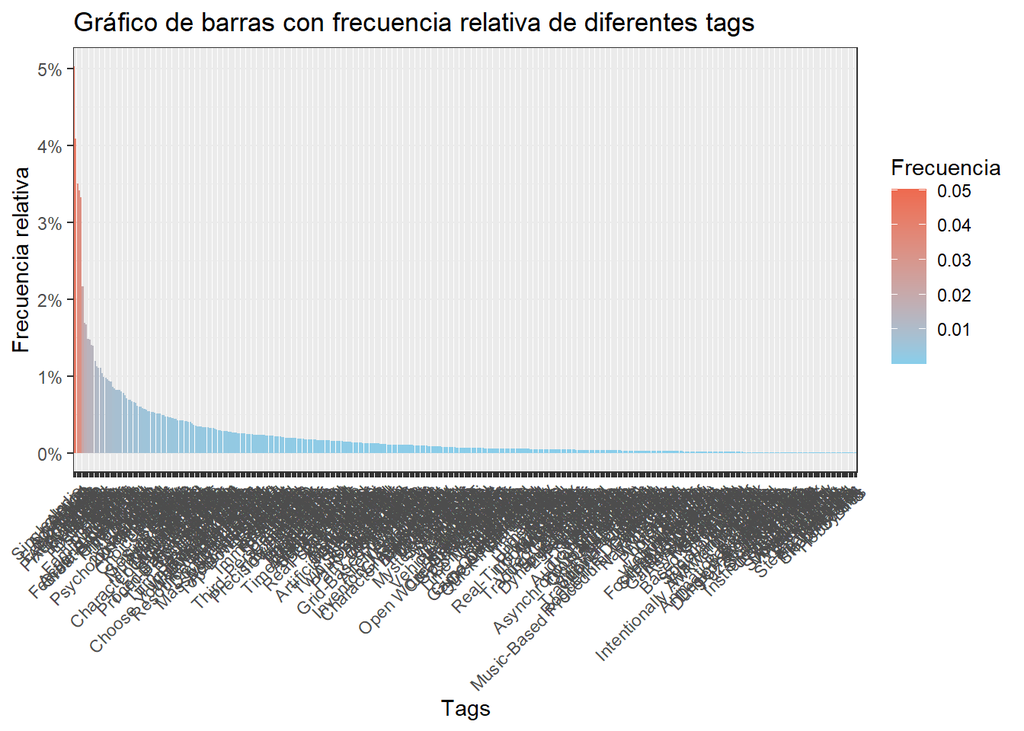

```r
tags_df <- data.frame(tags = unlist(tags_separados))
tags_df |> group_by(tags) |>  summarise(Frequency = n()) |> mutate(Frequency = Frequency/sum(Frequency), tags = reorder(tags, -Frequency)) |> ggplot(aes(x = tags, y = Frequency)) + geom_bar(stat = "identity", aes(fill = Frequency)) + scale_y_continuous(labels = scales::percent) + theme_bw() + labs(title = "Gráfico de barras con frecuencia relativa de diferentes tags", x = "Tags", y = "Frecuencia relativa") + scale_fill_gradient("Frecuencia", low = "skyblue", high = "coral2") + theme(axis.text.x = element_text(angle = 45, hjust = 1))
```

Como se puede comprobar, la cantidad de ‘tags’ es tal que la gráfica no es capaz de mostrarlas con claridad. Debido a esto, se llevarán a cabo dos gráficas más, una comprobará la frecuencia de los 25 ‘tags’ que lideran la gráfica anterior y, la otra, la frecuencia de las menos utilizadas.

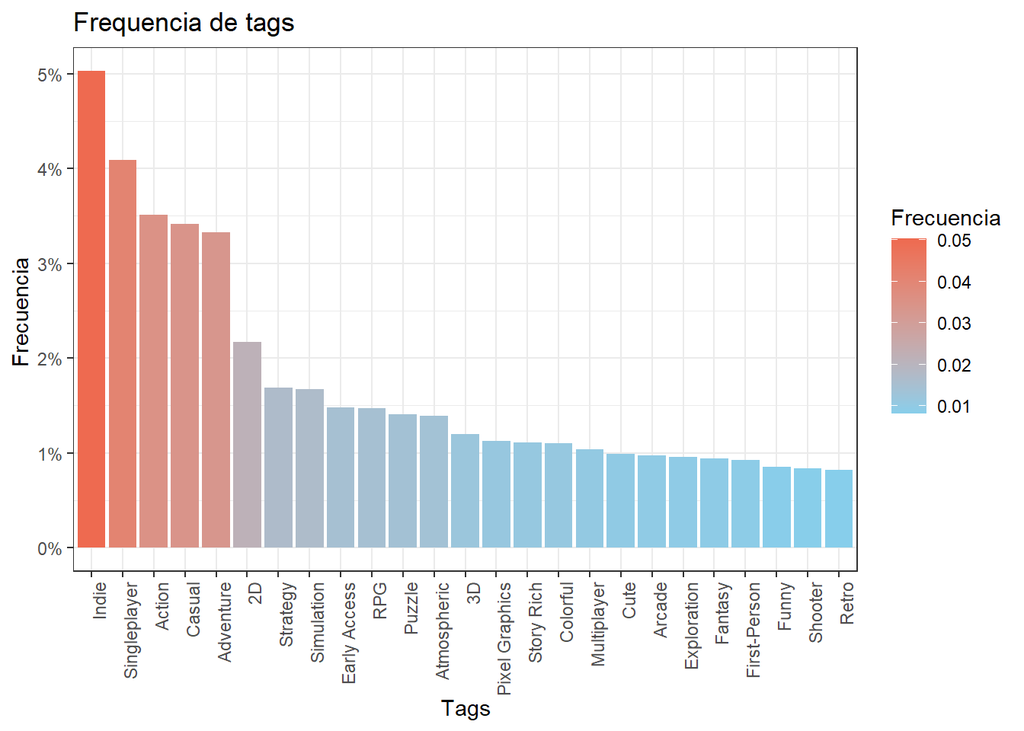

```r
tags_df <- data.frame(tags = unlist(tags_separados))

tags_freq <-tags_df %>%
  group_by(tags) %>%
  summarise(Frequency = n()) %>%
  mutate(Frequency = Frequency/ sum(Frequency)) %>%
  slice_max(Frequency, n=25) %>%
  mutate(tags = reorder(tags, -Frequency))

 ggplot(tags_freq, aes(x = tags, y = Frequency)) +
  # Añade un gráfico de barras
   geom_bar(stat = "identity", aes(fill = Frequency)) +
   scale_y_continuous(labels = scales::percent) +
  # Aplica un tema predeterminado en blanco y negro para la visualización.
  theme_bw() +
  # Establece los títulos del gráfico, eje x, y eje y.
  labs(title = "Frequencia de tags",
       x = "Tags",
       y = "Frecuencia ") +
   scale_fill_gradient("Frecuencia", low = "skyblue", high = "coral2") +
   theme(axis.text.x = element_text(angle = 90, hjust = 1))
```

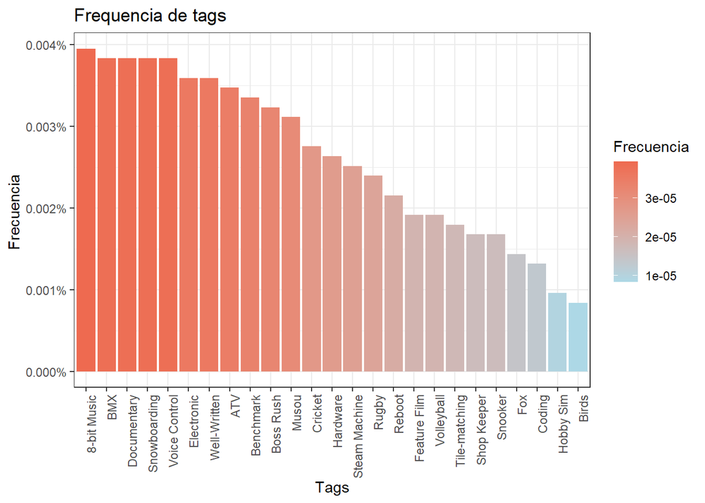

```r
tags_df <- data.frame(tags = unlist(tags_separados))

tags_freq <-tags_df %>%
  group_by(tags) %>%
  summarise(Frequency = n()) %>%
  mutate(Frequency = Frequency/ sum(Frequency)) %>%
  slice_min(Frequency, n=25) %>%
  mutate(tags = reorder(tags, -Frequency))

 ggplot(tags_freq, aes(x = tags, y = Frequency)) +
  # Añade un gráfico de barras
   geom_bar(stat = "identity", aes(fill = Frequency)) +
   scale_y_continuous(labels = scales::percent) +
  # Aplica un tema predeterminado en blanco y negro para la visualización.
  theme_bw() +
  # Establece los títulos del gráfico, eje x, y eje y.
  labs(title = "Frequencia de tags",
       x = "Tags",
       y = "Frecuencia ") +
   scale_fill_gradient("Frecuencia", low = "lightblue", high = "coral2") +
   theme(axis.text.x = element_text(angle = 90, hjust = 1))
```

## 4.2. Datos bivariantes

A continuación se procederá a comprobar diversas variables para estudiar si tienen relación entre ellas, tanto en el impacto de las opiniones de los usuarios como en el mercado.

Primeramente, se compararán los ‘tags’ con el año de salida para encontrar los más frecuentes según el paso del tiempo. Se continuará analizando los distintos ‘tags’ con el tiempo de duración de cada juego. Una vez terminado el análisis de los ‘tags’, se estudiará cómo los años han afectado a las críticas oficiales y si los jugadores están de acuerdo con estas puntuaciones.

### 4.2.0. Correlaciones

A modo de introducción, un breve resumen de las correlaciones entre los pares de datos que se analizarán.

Correlación ‘metacritic_rating’ y ‘year’:

```r
cor_año_criticos <- cor(datos$year, datos$metacritic_rating, use = "complete.obs")
cor_año_criticos
```

```
## [1] 0.04348633
```

Correlación ‘reviewer_rating’ y ‘metacritic_rating’:

```r
cor_usuarios_criticos <- cor(datos$reviewer_rating, datos$metacritic_rating, use = "complete.obs")
cor_usuarios_criticos
```

```
## [1] 0.5632193
```

Correlación ‘reviewer_rating’ y ‘to_beat_main’:

```r
cor_reviewer_main <- cor(datos$reviewer_rating, datos$to_beat_main, use = "complete.obs")
cor_reviewer_main
```

```
## [1] 0.01826266
```

Correlación ‘metacritic_rating’ y ‘to_beat_main’:

```r
cor_metacritic_main <- cor(datos$metacritic_rating, datos$to_beat_main, use = "complete.obs")
cor_metacritic_main
```

```
## [1] 0.1022525
```

Posteriormente se analizará en detalle qué significa cada resultado, pero para una mejor visualización, aquí una tabla y el gráfico de correlaciones a modo de resumen.

```r
# Crear un data frame con las correlaciones
correlations_df <- data.frame(
  Comparación = c("'year' vs 'metacritic_rating'",
                  "'reviewer_rating' vs 'metacritic_rating'",
                  "'reviewer_rating' vs 'to_beat_main'",
                  "'metacritic_rating' vs 'to_beat_main'"),
  Correlación = c(cor_año_criticos,
                  cor_usuarios_criticos,
                  cor_reviewer_main,
                  cor_metacritic_main)
)

# Mostrar la tabla
kable(correlations_df, caption = "Tabla de Correlaciones") %>%
  kable_styling("striped", full_width = F)
```

Tabla de Correlaciones

| Comparación | Correlación |
| --- | --- |
| ‘year’ vs ‘metacritic_rating’ | 0.0434863 |
| ‘reviewer_rating’ vs ‘metacritic_rating’ | 0.5632193 |
| ‘reviewer_rating’ vs ‘to_beat_main’ | 0.0182627 |
| ‘metacritic_rating’ vs ‘to_beat_main’ | 0.1022525 |

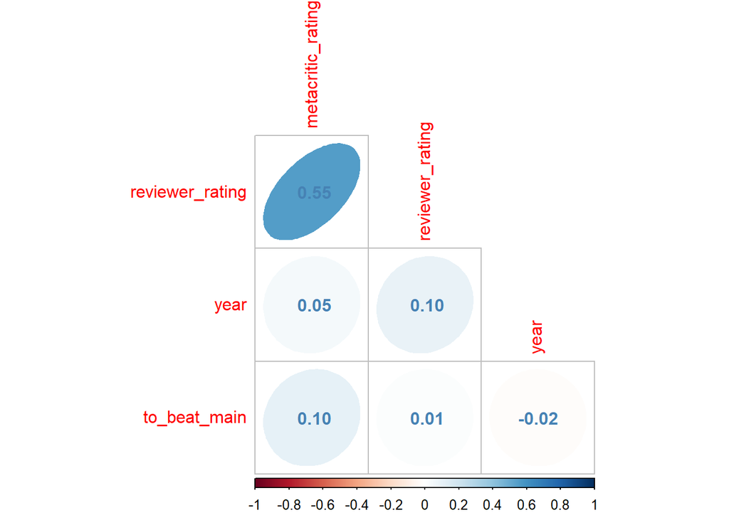

```r
# Seleccionar las variables
selected_data <- datos[, c("metacritic_rating", "reviewer_rating", "year", "to_beat_main")]

# Calcular la matriz de correlaciones
cor_matrix <- cor(selected_data, use = "complete.obs")

# Crear el gráfico de correlaciones
corrplot(cor_matrix, method = "ellipse",  # Usar elipses para representar correlaciones
         type = "lower",  # Mostrar solo la mitad inferior de la matriz
         addCoef.col = "steelblue",  # Color de los coeficientes de correlación
         diag = FALSE)  # Omitir la diagonal principal
```

### 4.2.1. Análisis de ‘tags’ y ‘year’

A continuación, se comparará el año de salida de los juegos con el género de juego más producido cada año, seguido de un resumen en tabla de lo que muestra el gráfico.

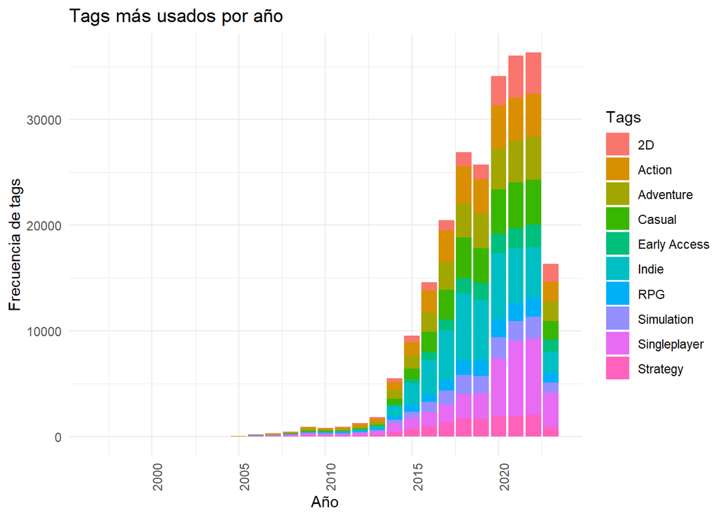

```r
# Paso 1: Separar los tags y mantener el año correspondiente
tags_separados <- datos %>%
  select(year, tags) %>%
  # Separar los tags en múltiples filas usando separate_rows
  separate_rows(tags, sep = "\\|")

# Paso 2: Contar las ocurrencias de cada tag por año
tags_por_año <- tags_separados %>%
  group_by(year, tags) %>%
  summarise(tag_count = n()) %>%
  ungroup()

# Paso 3: Filtrar los tags más frecuentes (opcional, por ejemplo, los 10 más frecuentes en total)
tags_mas_frecuentes <- tags_por_año %>%
  group_by(tags) %>%
  summarise(total_count = sum(tag_count)) %>%
  top_n(10, total_count)

# Paso 4: Filtrar los datos para mostrar solo los tags más frecuentes
tags_por_año_filtrado <- tags_por_año %>%
  filter(tags %in% tags_mas_frecuentes$tags)

# Paso 5: Graficar los tags más usados por año
ggplot(tags_por_año_filtrado, aes(x = year, y = tag_count, fill = tags)) +
  geom_bar(stat = "identity", position = "stack") +
  theme_minimal() +
  labs(title = "Tags más usados por año",
       x = "Año",
       y = "Frecuencia de tags",
       fill = "Tags") +
  theme(axis.text.x = element_text(angle = 90, hjust = 1))
```

```r
# Paso 1: Filtrar los datos de los últimos 10 años
ultimo_año <- max(datos$year, na.rm = TRUE)  # Obtener el año más reciente
datos_ultimos_10_años <- datos %>%
  filter(year >= (ultimo_año - 9))  # Filtrar los últimos 10 años

# Paso 2: Separar los tags para cada año dentro de los últimos 10 años
tags_separados_ultimos_10_años <- datos_ultimos_10_años %>%
  select(year, tags) %>%
  separate_rows(tags, sep = "\\|")  # Separar los tags en filas individuales

# Paso 3: Agrupar por año y por tag, y contar la frecuencia de los tags por año
conteo_tags_ultimos_10_años <- tags_separados_ultimos_10_años %>%
  group_by(year, tags) %>%
  summarise(frecuencia = n()) %>%
  arrange(year, desc(frecuencia))  # Ordenar por año y frecuencia descendente

# Paso 4: Seleccionar el tag más usado por cada año en los últimos 10 años
tags_mas_usados_ultimos_10_años <- conteo_tags_ultimos_10_años %>%
  group_by(year) %>%
  slice_max(frecuencia, n = 1)  # Obtener el tag más usado para cada año

# Mostrar los tags más usados por año en los últimos 10 años
print(tags_mas_usados_ultimos_10_años)
```

```
## # A tibble: 10 × 3
## # Groups:   year [10]
##     year tags         frecuencia
##    <dbl> <chr>             <int>
##  1  2014 Indie               995
##  2  2015 Indie              2049
##  3  2016 Indie              3256
##  4  2017 Indie              4662
##  5  2018 Indie              6325
##  6  2019 Indie              5710
##  7  2020 Indie              6246
##  8  2021 Singleplayer       7062
##  9  2022 Singleplayer       7269
## 10  2023 Singleplayer       3247
```

### 4.2.2. Análisis de ‘tags’ y tiempo de jugabilidad.

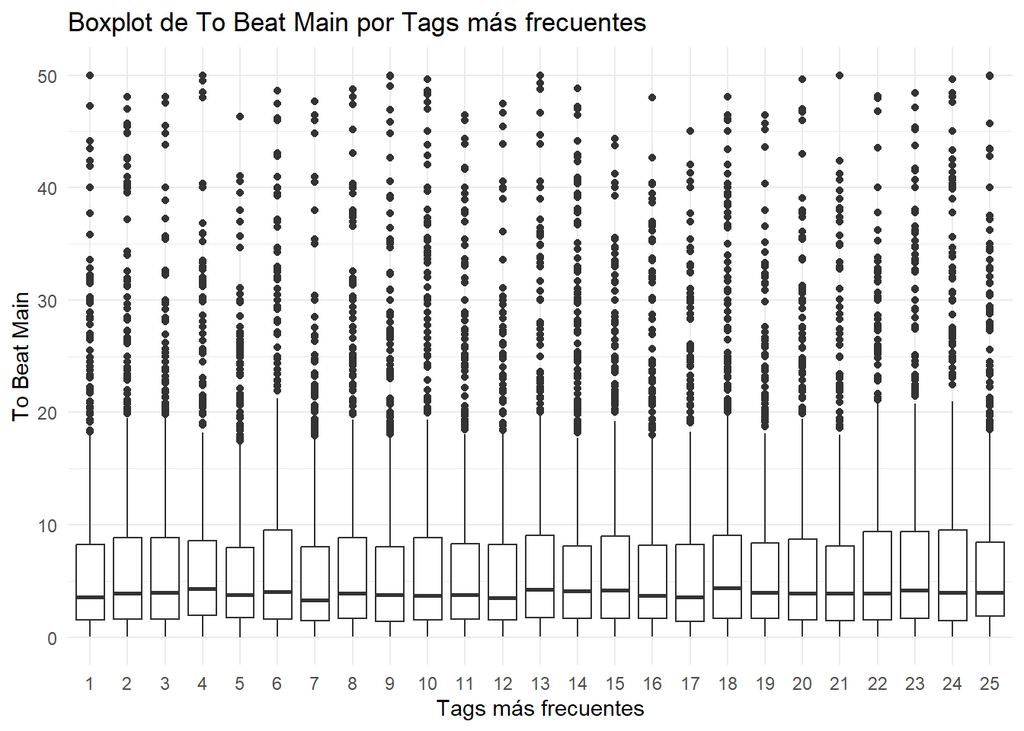

```r
datos$tags_freq <- sample(1:25, 63543, replace = TRUE)

# Filtrar valores por debajo de un umbral de 50 horas
datos_filtrados_main3 <- datos %>% filter(to_beat_main <= 50)

# Generar el boxplot con los datos filtrados
ggplot(datos_filtrados_main3, aes(x = factor(tags_freq), y = to_beat_main)) +
  geom_boxplot() +
  labs(x = "Tags más frecuentes", y = "To Beat Main", title = "Boxplot de To Beat Main por Tags más frecuentes") +
  theme_minimal()
```

El gráfico muestra que la mayoría de los juegos tienen un tiempo de finalización relativamente corto, por debajo de 10 horas. Los puntos son los valores atípicos.

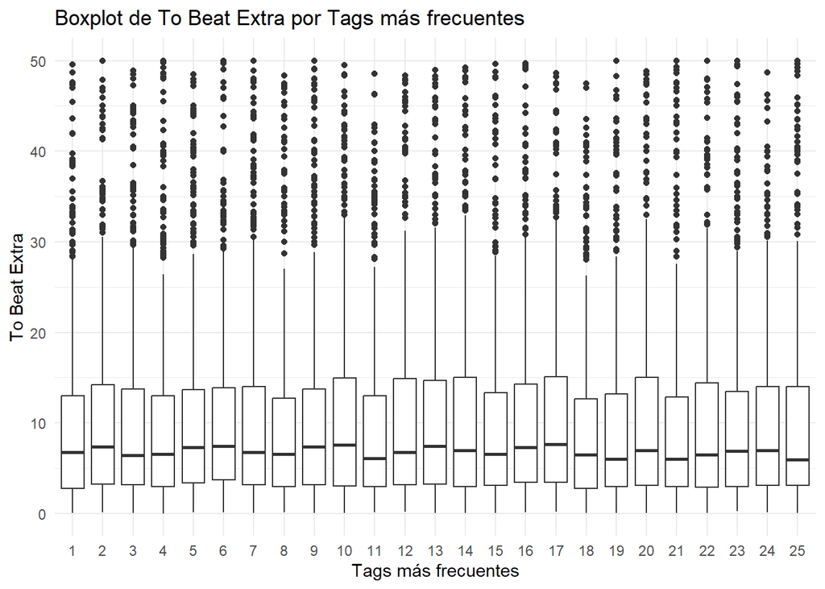

```r
datos$tags_freq <- sample(1:25, 63543, replace = TRUE)

# Filtrar valores por debajo de un umbral de 50 horas
datos_filtrados_extra3 <- datos %>% filter(to_beat_extra <= 50)

# Generar el boxplot con los datos filtrados
ggplot(datos_filtrados_extra3, aes(x = factor(tags_freq), y = to_beat_extra)) +
  geom_boxplot() +
  labs(x = "Tags más frecuentes", y = "To Beat Extra", title = "Boxplot de To Beat Extra por Tags más frecuentes") +
  theme_minimal()
```

En este segundo gráfico se puede observar cómo los valores ascienden un poco estando entre las 3 y las 15 horas.

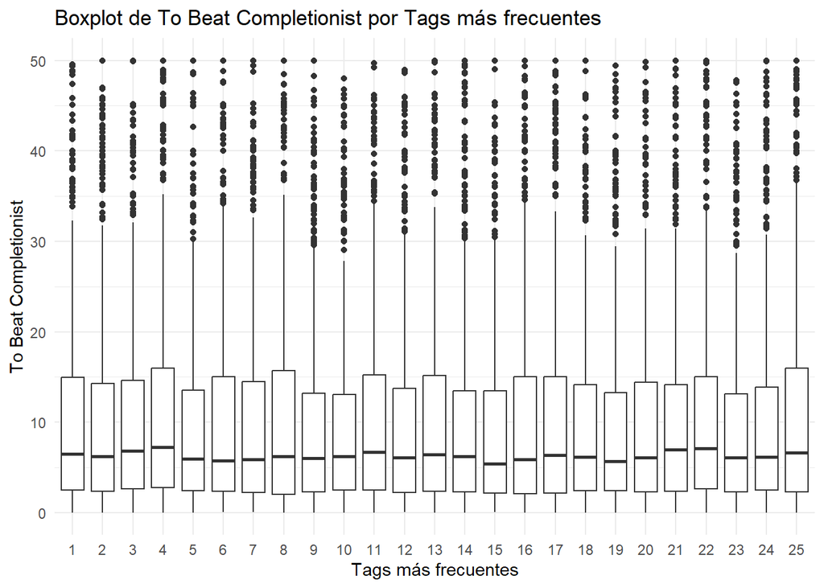

```r
datos$tags_freq <- sample(1:25, 63543, replace = TRUE)

# Filtrar valores por debajo de un umbral de 50 horas
datos_filtrados_completionist3 <- datos %>% filter(to_beat_completionist <= 50)

# Generar el boxplot con los datos filtrados
ggplot(datos_filtrados_completionist3, aes(x = factor(tags_freq), y = to_beat_completionist)) +
  geom_boxplot() +
  labs(x = "Tags más frecuentes", y = "To Beat Completionist", title = "Boxplot de To Beat Completionist por Tags más frecuentes") +
  theme_minimal()
```

Mientras que en este último ya se puede apreciar cómo los valores aumentan, pasando en algunos casos las 20 horas. Esto es de esperar, ya que ‘to_beat_completionist’ incluye conseguir todos los logros del juego y no tan solo completar la historia principal.

### 4.2.3. Análisis de ‘year’ y ‘metacritic_rating’

Se empieza creando una tabla comparativa y calculando la covarianza y correlación:

```r
tabla_comparativa_años_criticas <- datos |>
  filter(!is.na(year), !is.na(metacritic_rating)) |>  # Excluir NA
  mutate(rango_años = cut(year, breaks = 7),
         rango_criticas = cut(metacritic_rating, breaks = 7)) |>
  count(rango_años, rango_criticas)

kable(tabla_comparativa_años_criticas)
```

| rango_años | rango_criticas | n |
| --- | --- | --- |
| (1997,2001] | (53,64] | 1 |
| (1997,2001] | (86,97.1] | 2 |
| (2001,2004] | (64,75] | 2 |
| (2001,2004] | (75,86] | 4 |
| (2001,2004] | (86,97.1] | 3 |
| (2004,2008] | (31,42] | 1 |
| (2004,2008] | (42,53] | 2 |
| (2004,2008] | (53,64] | 14 |
| (2004,2008] | (64,75] | 64 |
| (2004,2008] | (75,86] | 91 |
| (2004,2008] | (86,97.1] | 42 |
| (2008,2012] | (19.9,31] | 3 |
| (2008,2012] | (31,42] | 6 |
| (2008,2012] | (42,53] | 19 |
| (2008,2012] | (53,64] | 74 |
| (2008,2012] | (64,75] | 165 |
| (2008,2012] | (75,86] | 180 |
| (2008,2012] | (86,97.1] | 39 |
| (2012,2016] | (19.9,31] | 3 |
| (2012,2016] | (31,42] | 18 |
| (2012,2016] | (42,53] | 58 |
| (2012,2016] | (53,64] | 206 |
| (2012,2016] | (64,75] | 452 |
| (2012,2016] | (75,86] | 368 |
| (2012,2016] | (86,97.1] | 44 |
| (2016,2019] | (19.9,31] | 3 |
| (2016,2019] | (31,42] | 13 |
| (2016,2019] | (42,53] | 62 |
| (2016,2019] | (53,64] | 183 |
| (2016,2019] | (64,75] | 491 |
| (2016,2019] | (75,86] | 505 |
| (2016,2019] | (86,97.1] | 60 |
| (2019,2023] | (31,42] | 2 |
| (2019,2023] | (42,53] | 12 |
| (2019,2023] | (53,64] | 44 |
| (2019,2023] | (64,75] | 224 |
| (2019,2023] | (75,86] | 385 |
| (2019,2023] | (86,97.1] | 47 |

Covarianza:

```r
cov_año_criticos <- cov(datos$year, datos$metacritic_rating, use = "complete.obs")
cov_año_criticos
```

```
## [1] 1.87649
```

Correlación:

```r
cor_año_criticos <- cor(datos$year, datos$metacritic_rating, use = "complete.obs")
cor_año_criticos
```

```
## [1] 0.04348633
```

Gráfica de dispersión:

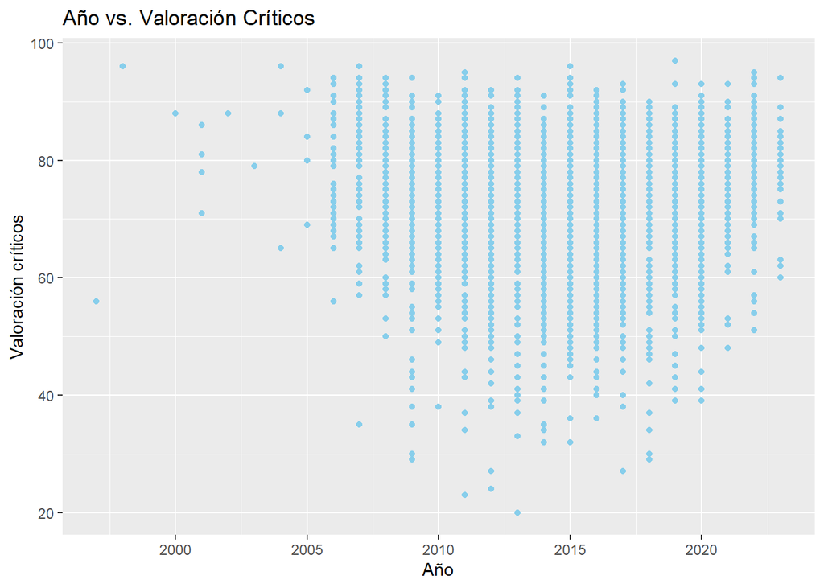

```r
ggplot(datos, aes(x = year, y = metacritic_rating, color = factor(tags_df))) +
  geom_point(color = "skyblue") +
  labs(x = "Año", y = "Valoración críticos") +
  ggtitle("Año vs. Valoración Críticos") +
  scale_color_discrete(name = "Tags")
```

Como era esperable, se puede apreciar que hay mucha variedad en las valoraciones de los críticos, ya que cada juego es diferente, sin embargo también es posible observar ciertas tendencias sobre los años y, según los expertos, qué años tuvieron “mejores” salidas en la industria.

Tomando en cuenta sobre todo los años de los que se tiene más datos así como que es una valoración sobre 100, desde el 2020 se percibe una supuesta mejora en las críticas, indicando que se han sacado al público mejores obras audiovisuales. Por el contrario, desde el 2009 hasta 2013 hubo una peor calidad.

Regresión lineal:

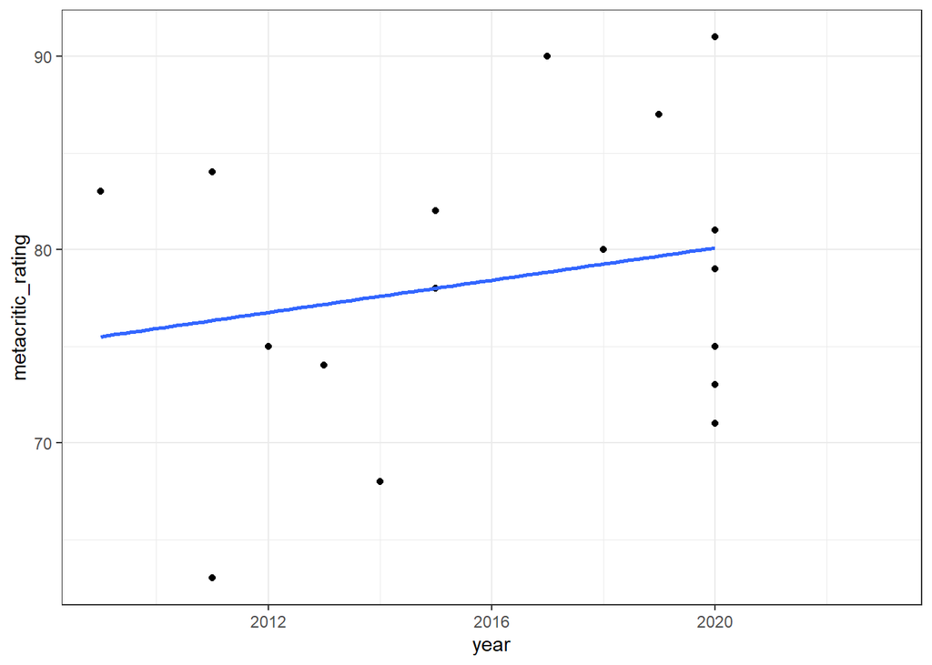

```r
datos |>
  slice(1:100) |>
  select(year, metacritic_rating) |>
  ggplot(aes(x=year, y = metacritic_rating)) +
  geom_point() +
  theme_bw() +
  geom_smooth(method = lm, se = FALSE)
```

Es posible entonces determinar que la pendiente de la regresión lineal no es muy positiva, confirmando lo dicho con la correlación y covarianza.

```r
reg_año_critica <- lm(metacritic_rating ~ year, data = datos)
summary(reg_año_critica)
```

```
##
## Call:
## lm(formula = metacritic_rating ~ year, data = datos)
##
## Residuals:
##     Min      1Q  Median      3Q     Max
## -52.548  -5.548   1.554   7.340  25.136
##
## Coefficients:
##               Estimate Std. Error t value Pr(>|t|)
## (Intercept) -153.48449   83.36020  -1.841  0.06567 .
## year           0.11229    0.04136   2.715  0.00666 **
## ---
## Signif. codes:  0 '***' 0.001 '**' 0.01 '*' 0.05 '.' 0.1 ' ' 1
##
## Residual standard error: 10.55 on 3890 degrees of freedom
##   (59651 observations deleted due to missingness)
## Multiple R-squared:  0.001891,   Adjusted R-squared:  0.001634
## F-statistic:  7.37 on 1 and 3890 DF,  p-value: 0.006661
```

La regresión lineal sugiere que hay una relación positiva entre el año de lanzamiento del juego y su calificación por expertos, aunque la magnitud de esta relación es muy pequeña. Otros factores no considerados en esta sección del análisis podrían tener un mayor impacto en las calificaciones.

### 4.2.4. Análisis de ‘metacritic_rating’ y ‘rewiewer_rating’

Se va a comparar las puntuaciones de los críticos oficiales con la puntuación dada por los jugadores (reviewers). Para ello se han seleccionado los 10 primeros juegos de la tabla, ignorando los juegos que no tenían valores de ‘metacritic_rating’ o ‘rewiewer_rating’.

Gráfico de barras ‘metacritic_rating’ y ‘rewiewer_rating’:

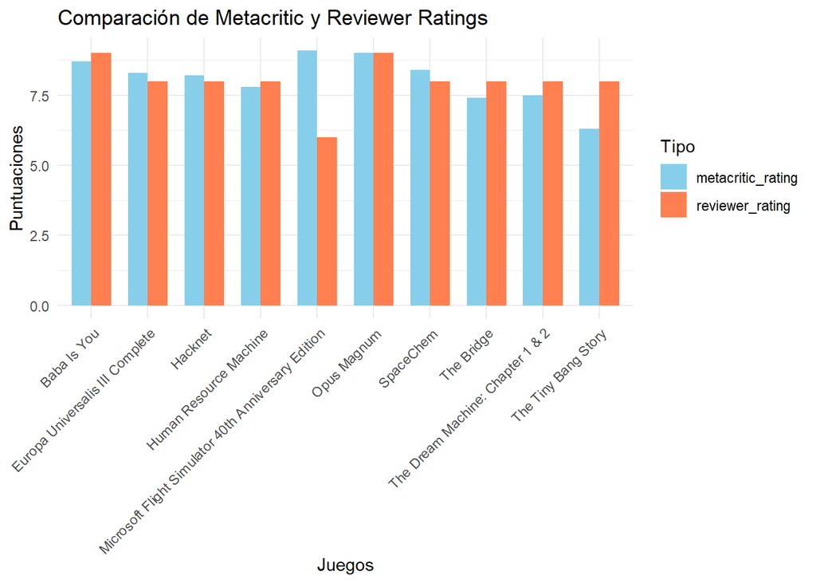

```r
# Transformar los datos al formato largo, seleccionar los 10 primeros y ajustar metacritic_rating
datos_long <- datos %>%
  # Filtrar filas donde metacritic_rating o reviewer_rating son NA
  filter(!is.na(metacritic_rating) & !is.na(reviewer_rating)) %>%
  slice_head(n = 10) %>%
  mutate(metacritic_rating = metacritic_rating / 10) %>%  # Ajustar la puntuación a sobre 10
  pivot_longer(cols = c(metacritic_rating, reviewer_rating),
               names_to = "tipo",
               values_to = "valor")

# Crear el gráfico de barras
ggplot(datos_long, aes(x = name, y = valor, fill = tipo)) +
  geom_bar(stat = "identity", position = position_dodge(), width = 0.7) +  # Ajustar ancho de barras
  labs(title = "Comparación de Metacritic y Reviewer Ratings",
       x = "Juegos",
       y = "Puntuaciones",
       fill = "Tipo") +
  scale_fill_manual(values = c("metacritic_rating" = "skyblue", "reviewer_rating" = "coral")) +  # Cambiar colores
  theme_minimal() +  # Cambiar a un tema minimalista
  theme(axis.text.x = element_text(angle = 45, hjust = 1))  # Rotar etiquetas
```

Con esto se puede observar que ambas puntuaciones suelen tener valores muy cercanos, incluso iguales, exceptuando algunos casos como por ejemplo “Microsoft Flight Simulator”, que ha sido mejor puntuado por los críticos, o “The Tiny Bang Story, que ha sido mejor puntuado por los jugadores.

También se ha realizado un gráfico de dispersión para visualizar mejor la correlación entre las dos puntuaciones.

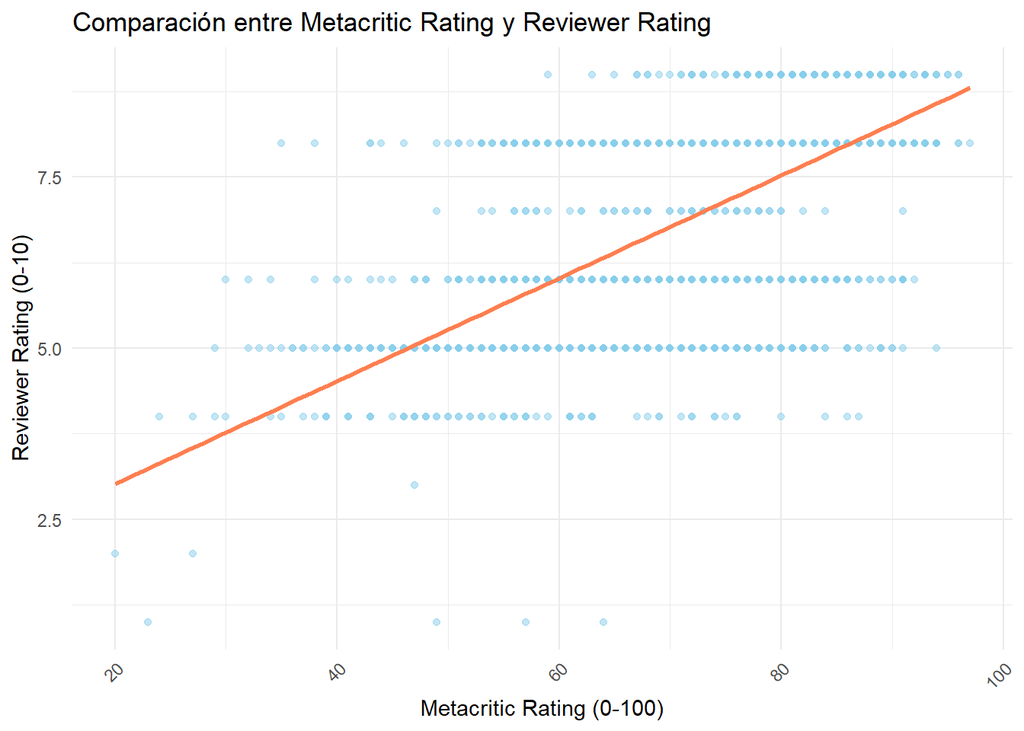

```r
ggplot(datos, aes(x = metacritic_rating, y = reviewer_rating)) +
  geom_point(alpha = 0.5, color = "skyblue") +  # Puntos de color azul con algo de transparencia
  geom_smooth(method = "lm", color = "coral", se = FALSE) +  # Línea de tendencia lineal
  theme_minimal() +
  labs(title = "Comparación entre Metacritic Rating y Reviewer Rating",
       x = "Metacritic Rating (0-100)",
       y = "Reviewer Rating (0-10)") +
  theme(axis.text.x = element_text(angle = 45, hjust = 1))
```

Correlación:

```r
cor_año_criticos <- cor(datos$reviewer_rating, datos$metacritic_rating, use = "complete.obs")
cor_año_criticos
```

```
## [1] 0.5632193
```

```r
reg_reviewer_metacritic<- lm(reviewer_rating ~ metacritic_rating, data = datos)
summary(reg_reviewer_metacritic)
```

```
##
## Call:
## lm(formula = reviewer_rating ~ metacritic_rating, data = datos)
##
## Residuals:
##     Min      1Q  Median      3Q     Max
## -5.3231 -0.9239  0.2542  0.8507  3.8551
##
## Coefficients:
##                   Estimate Std. Error t value Pr(>|t|)
## (Intercept)       1.516159   0.129939   11.67   <2e-16 ***
## metacritic_rating 0.075108   0.001765   42.56   <2e-16 ***
## ---
## Signif. codes:  0 '***' 0.001 '**' 0.01 '*' 0.05 '.' 0.1 ' ' 1
##
## Residual standard error: 1.162 on 3899 degrees of freedom
##   (59642 observations deleted due to missingness)
## Multiple R-squared:  0.3172, Adjusted R-squared:  0.317
## F-statistic:  1811 on 1 and 3899 DF,  p-value: < 2.2e-16
```

### 4.2.5. Análisis de ‘reviewer_rating’ y ‘metacritic_rating’ vs ‘to_beat_main’

Se han realizado dos gráficos de dispersión para ver si había algún tipo de correlación entre la puntuación de los críticos y los reviewers, y el tiempo para completar un juego.

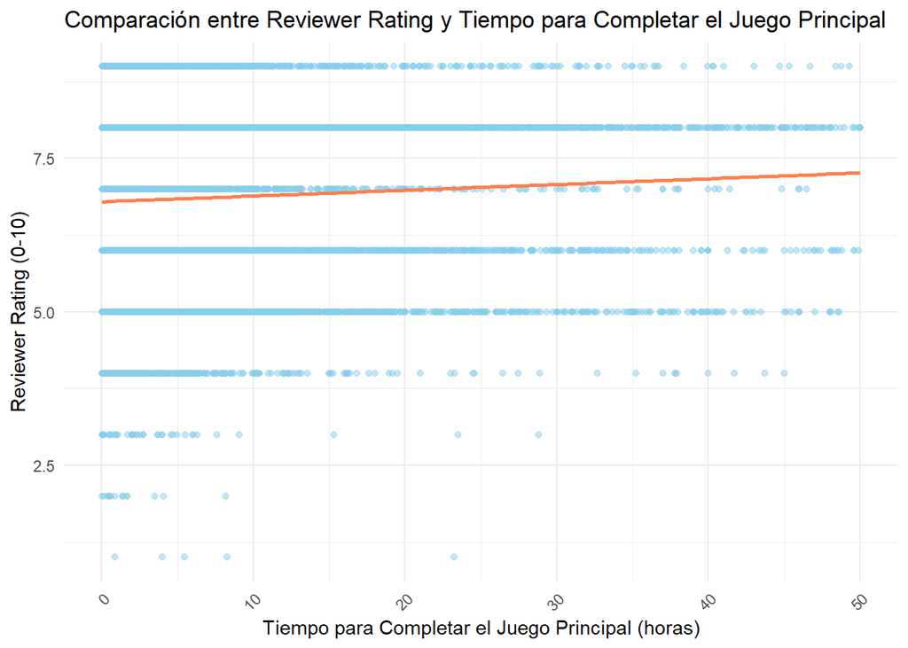

```r
# Filtrar los datos para mantener solo juegos con un tiempo de completar entre 0 y 100 horas
datos_filtrados <- datos %>%
  filter(to_beat_main >= 0 & to_beat_main <= 50)

# Gráfico de dispersión para comparar reviewer_rating y to_beat_main
ggplot(datos_filtrados, aes(x = to_beat_main, y = reviewer_rating)) +
  geom_point(alpha = 0.5, color = "skyblue") +  # Puntos de color azul con algo de transparencia
  geom_smooth(method = "lm", color = "coral", se = FALSE) +  # Línea de tendencia lineal
  theme_minimal() +
  labs(title = "Comparación entre Reviewer Rating y Tiempo para Completar el Juego Principal",
       x = "Tiempo para Completar el Juego Principal (horas)",
       y = "Reviewer Rating (0-10)") +
  theme(axis.text.x = element_text(angle = 45, hjust = 1))
```

Correlación:

```r
cor_reviewer_main <- cor(datos$reviewer_rating, datos$to_beat_main, use = "complete.obs")
cor_reviewer_main
```

```
## [1] 0.01826266
```

```r
reg_reviewer_main<- lm(reviewer_rating ~ to_beat_main, data = datos)
summary(reg_reviewer_main)
```

```
##
## Call:
## lm(formula = reviewer_rating ~ to_beat_main, data = datos)
##
## Residuals:
##     Min      1Q  Median      3Q     Max
## -5.8752 -0.8717  0.1396  1.1373  2.1398
##
## Coefficients:
##               Estimate Std. Error t value Pr(>|t|)
## (Intercept)  6.8601390  0.0113213 605.948   <2e-16 ***
## to_beat_main 0.0006457  0.0002809   2.298   0.0216 *
## ---
## Signif. codes:  0 '***' 0.001 '**' 0.01 '*' 0.05 '.' 0.1 ' ' 1
##
## Residual standard error: 1.383 on 15831 degrees of freedom
##   (47710 observations deleted due to missingness)
## Multiple R-squared:  0.0003335,  Adjusted R-squared:  0.0002704
## F-statistic: 5.282 on 1 and 15831 DF,  p-value: 0.02156
```

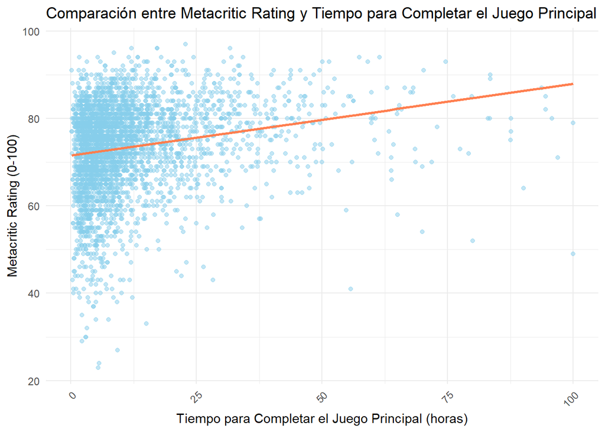

```r
# Filtrar los datos para mantener solo juegos con un tiempo de completar entre 0 y 100 horas
datos_filtrados <- datos %>%
  filter(to_beat_main >= 0 & to_beat_main <= 100)

# Gráfico de dispersión para comparar metacritic_rating y to_beat_main
ggplot(datos_filtrados, aes(x = to_beat_main, y = metacritic_rating)) +
  geom_point(alpha = 0.5, color = "skyblue") +  # Puntos de color azul con algo de transparencia
  geom_smooth(method = "lm", color = "coral", se = FALSE) +  # Línea de tendencia lineal
  theme_minimal() +
  labs(title = "Comparación entre Metacritic Rating y Tiempo para Completar el Juego Principal",
       x = "Tiempo para Completar el Juego Principal (horas)",
       y = "Metacritic Rating (0-100)") +
  theme(axis.text.x = element_text(angle = 45, hjust = 1))
```

Correlación:

```r
cor_metacritic_main <- cor(datos$metacritic_rating, datos$to_beat_main, use = "complete.obs")
cor_metacritic_main
```

```
## [1] 0.1022525
```

```r
reg_metacritic_main<- lm(metacritic_rating ~ to_beat_main, data = datos)
summary(reg_metacritic_main)
```

```
##
## Call:
## lm(formula = metacritic_rating ~ to_beat_main, data = datos)
##
## Residuals:
##     Min      1Q  Median      3Q     Max
## -50.330  -5.348   1.615   6.783  23.264
##
## Coefficients:
##              Estimate Std. Error t value Pr(>|t|)
## (Intercept)  73.20157    0.18198 402.258  < 2e-16 ***
## to_beat_main  0.02345    0.00391   5.998 2.21e-09 ***
## ---
## Signif. codes:  0 '***' 0.001 '**' 0.01 '*' 0.05 '.' 0.1 ' ' 1
##
## Residual standard error: 10.13 on 3405 degrees of freedom
##   (60136 observations deleted due to missingness)
## Multiple R-squared:  0.01046,    Adjusted R-squared:  0.01016
## F-statistic: 35.98 on 1 and 3405 DF,  p-value: 2.205e-09
```